# L12

```r
library(tidymodels)
library(tidyverse)
library(GGally)
library(discrim)
library(kknn)
```

## Exercise 1

Divide the dataset into training and comparison parts by keeping proportions of the variable default (75% for training), form a 5-fold cross-validation set from training part, again keeping proportions fixed.

```r
table(ISLR::Default$default)
```

```
  No  Yes
9667  333
```

```r
# Split data into training and testing (comparison) sets
set.seed(20241121)
default_split <- initial_split(ISLR::Default, prop = 0.75, strata = default)
train_data <- training(default_split)
test_data <- testing(default_split)

# 5-fold cross-validation on the training set with class proportions preserved
cv_folds <- vfold_cv(train_data, v = 5, strata = default)
```

# Fitting models for probability prediction

## Exercise 2

Fit logistic regression, QDA and generalised additive models (gam with a smoothing term with respect to income) to training set and compute mean log loss on the comparison set. Which one has the smallest loss? Hint: when computing mean log loss, it is a good idea to indicate with event_level=“first/second”, which level of the outcome variable corresponds to the event for which we provide probabilities.

```r
rec = recipe(default~., data=train_data)

wf_base = workflow()|> add_recipe(rec)

wf_log_reg = wf_base |> add_model(logistic_reg())

wf_final_log_reg = wf_log_reg |> fit(train_data)
```

```r
levels(train_data$default)
```

```
[1] "No"  "Yes"
```

[output not shown]

[output cut: 990 more lines]

```r
augment(wf_final_log_reg, new_data = test_data) |> mn_log_loss(truth = default, .pred_Yes, event_level = "second")
```

| .metric | .estimator | .estimate |
| --- | --- | --- |
| mn_log_loss | binary | 0.07366807 |

```r
predict(wf_final_log_reg, test_data, type = "prob")
```

| .pred_No | .pred_Yes |
| --- | --- |
| 0.9980859 | 1.914120e-03 |
| 0.9996752 | 3.247963e-04 |
| 0.9913626 | 8.637410e-03 |
| 0.9992139 | 7.860839e-04 |
| 0.9204208 | 7.957919e-02 |
| 0.9961980 | 3.802048e-03 |
| 0.9655349 | 3.446506e-02 |
| 0.9989401 | 1.059904e-03 |
| 0.9998529 | 1.470834e-04 |
| 0.9991574 | 8.425960e-04 |

[output cut: 990 more lines]

```r
wf_qda = wf_base |> add_model(discrim_quad())

wf_final_qda = wf_qda |> fit(train_data)

augment(wf_final_qda, new_data = test_data) |> mn_log_loss(truth = default, .pred_Yes, event_level = "second")
```

| .metric | .estimator | .estimate |
| --- | --- | --- |
| mn_log_loss | binary | 0.07632428 |

```r
NA
```

```r
gam_spec <- gen_additive_mod(mode = "classification")

wf_gam = wf_base |> add_model(gam_spec) |> add_formula(default~student+balance+s(income))
```

```
Error in `add_formula()`:
! A formula cannot be added when a recipe already exists.
Backtrace:
 1. workflows::add_formula(...)
```

## Exercise 3

If we want to use kNN for probability estimation, we should make sure that the number of neighbors is large enough to get reasonable probability estimates. Use cross-validation data to select appropriate number of neighbors from 11,21,31 for predicting probability of default. Compute mean log loss on the test set.

```r
# Define a function to fit kNN and calculate log loss
calculate_knn_loss <- function(neighbors) {
  knn_spec <- nearest_neighbor(neighbors = neighbors) %>%
    set_engine("kknn") %>%
    set_mode("classification")

  wf_knn = wf_base |> add_model(knn_spec)

  wf_final_knn = wf_knn |> fit(data=train_data)

  print(augment(wf_final_knn, new_data = test_data))

  augment(wf_final_knn, new_data = test_data) |> mn_log_loss(truth = default, .pred_Yes, event_level = "second")
}

# Calculate losses for k = 11, 21, and 31
knn_loss_11 <- calculate_knn_loss(11)
```

| .pred_class | .pred_No | .pred_Yes | default | student | balance | income |
| --- | --- | --- | --- | --- | --- | --- |
| No | 1.00000000 | 0.000000000 | No | No | 1073.54916 | 31767.139 |
| No | 1.00000000 | 0.000000000 | No | No | 286.23256 | 45042.413 |
| No | 1.00000000 | 0.000000000 | No | No | 0.00000 | 50265.312 |
| No | 1.00000000 | 0.000000000 | No | Yes | 527.54018 | 17636.540 |
| No | 1.00000000 | 0.000000000 | No | No | 954.26179 | 32457.509 |
| No | 1.00000000 | 0.000000000 | No | No | 641.98439 | 30466.103 |
| No | 1.00000000 | 0.000000000 | No | No | 773.21172 | 34353.314 |
| No | 1.00000000 | 0.000000000 | No | No | 855.00852 | 25211.332 |
| No | 1.00000000 | 0.000000000 | No | Yes | 1119.56935 | 16556.070 |
| No | 1.00000000 | 0.000000000 | No | Yes | 584.90489 | 22429.935 |

[output cut: 990 more lines]

```r
knn_loss_21 <- calculate_knn_loss(21)
```

| .pred_class | .pred_No | .pred_Yes | default | student | balance | income |
| --- | --- | --- | --- | --- | --- | --- |
| No | 1.00000000 | 0.000000000 | No | No | 1073.54916 | 31767.139 |
| No | 1.00000000 | 0.000000000 | No | No | 286.23256 | 45042.413 |
| No | 1.00000000 | 0.000000000 | No | No | 0.00000 | 50265.312 |
| No | 1.00000000 | 0.000000000 | No | Yes | 527.54018 | 17636.540 |
| No | 1.00000000 | 0.000000000 | No | No | 954.26179 | 32457.509 |
| No | 1.00000000 | 0.000000000 | No | No | 641.98439 | 30466.103 |
| No | 1.00000000 | 0.000000000 | No | No | 773.21172 | 34353.314 |
| No | 1.00000000 | 0.000000000 | No | No | 855.00852 | 25211.332 |
| No | 1.00000000 | 0.000000000 | No | Yes | 1119.56935 | 16556.070 |
| No | 1.00000000 | 0.000000000 | No | Yes | 584.90489 | 22429.935 |

[output cut: 990 more lines]

```r
knn_loss_31 <- calculate_knn_loss(31)
```

| .pred_class | .pred_No | .pred_Yes | default | student | balance | income |
| --- | --- | --- | --- | --- | --- | --- |
| No | 1.0000000 | 0.0000000000 | No | No | 1073.54916 | 31767.139 |
| No | 1.0000000 | 0.0000000000 | No | No | 286.23256 | 45042.413 |
| No | 1.0000000 | 0.0000000000 | No | No | 0.00000 | 50265.312 |
| No | 1.0000000 | 0.0000000000 | No | Yes | 527.54018 | 17636.540 |
| No | 1.0000000 | 0.0000000000 | No | No | 954.26179 | 32457.509 |
| No | 1.0000000 | 0.0000000000 | No | No | 641.98439 | 30466.103 |
| No | 1.0000000 | 0.0000000000 | No | No | 773.21172 | 34353.314 |
| No | 1.0000000 | 0.0000000000 | No | No | 855.00852 | 25211.332 |
| No | 1.0000000 | 0.0000000000 | No | Yes | 1119.56935 | 16556.070 |
| No | 1.0000000 | 0.0000000000 | No | Yes | 584.90489 | 22429.935 |

[output cut: 990 more lines]

```r
# Output losses for comparison
knn_loss_11
```

| .metric | .estimator | .estimate |
| --- | --- | --- |
| mn_log_loss | binary | 0.3366572 |

```r
knn_loss_21
```

| .metric | .estimator | .estimate |
| --- | --- | --- |
| mn_log_loss | binary | 0.2548781 |

```r
knn_loss_31
```

| .metric | .estimator | .estimate |
| --- | --- | --- |
| mn_log_loss | binary | 0.2279931 |

```r
NA
```

[output not shown]

## Exercise 4

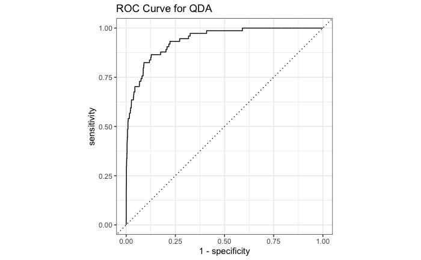

```r
qda_predictions <- augment(wf_final_qda, new_data = test_data)

qda_roc_data <- qda_predictions |> roc_curve(
  truth = default,          # True labels
  .pred_Yes,  # Probabilities for the positive class "Yes"
  event_level = "second"               # "second" because "Yes" is the positive class
)

# Plot ROC curve for QDA
qda_roc_plot <- autoplot(qda_roc_data) +
  ggtitle("ROC Curve for QDA")

# Display QDA ROC plot
print(qda_roc_plot)
```

[figure not shown]

## Exercise 5

Consider the case when predicting “No” for defaulting application costs 5 times more than predicting “Yes” for application which does not default. Which probability level should we use in Bayes classificator in this case? Compute the classification losses of the classifies constructed from previously fitted methods on the comparison data. Which point on a ROC curve of QDA method computed for training data corresponds to the optimal split?

```r
# Classification with adjusted threshold
adjust_threshold <- function(probs, threshold) {
  ifelse(probs >= threshold, "Yes", "No")
}

# Calculate adjusted predictions and losses for each model
qda_adjusted_pred <- adjust_threshold(qda_pred$.pred_default, 0.167)
knn_adjusted_pred <- adjust_threshold(knn_pred$.pred_default, 0.167)

# Compute loss for each model
qda_loss_adj <- classification_cost(truth = test_data$default, estimate = qda_adjusted_pred)
knn_loss_adj <- classification_cost(truth = test_data$default, estimate = knn_adjusted_pred)

qda_loss_adj
knn_loss_adj
```

[output not shown]